# Final_LM

Lisa McDaniel

11/11/2020

Load dataset and saved as *FiveYear*. Filled *Location* and *Miles* for each record in the dataframe; renamed several columns. Showing the first 6 rows of the dataframe in the output.

```r
library(readxl)
library(tidyverse)
library(dplyr)

FiveYear <- read_excel('C:/Users/lisa.mcdaniel/DS202/Final_Project/Final_Project/2021_2025_5YrProg_Highway_Program.xlsx')

FiveYear <- FiveYear %>%
  fill(Location, .direction = "down") %>%
  rename(District = `Iowa DOT District`, Route = `Project Route`,
         Work = `Type of Work`) %>%
  group_by(Location) %>%
  fill(Miles, .direction = "down") %>%
  mutate(District = as.numeric(District))

head(FiveYear)
```

```
## # A tibble: 6 x 20
## # Groups:   Location [6]
##   State County `Latitude\r\n(T~ `Latitude\r\n(D~ Latitude `Longitude\r\n(~
##   <chr> <chr>             <dbl>            <dbl> <chr>               <dbl>
## 1 Iowa  Adair            412043             41.3 41° 20'~          -942818
## 2 Iowa  Adair                NA             NA   <NA>                   NA
## 3 Iowa  Adair                NA             NA   <NA>                   NA
## 4 Iowa  Adair                NA             NA   <NA>                   NA
## 5 Iowa  Adair                NA             NA   <NA>                   NA
## 6 Iowa  Adair                NA             NA   <NA>                   NA
## # ... with 14 more variables: `Longitude\r\n(Decimal)` <dbl>, Longitude <chr>,
## #   District <dbl>, Route <dbl>, Location <chr>, `State Share` <chr>,
## #   `Reschedule if the HTF Becomes Insolvent` <chr>, Miles <dbl>, Work <chr>,
## #   `2021` <dbl>, `2022` <dbl>, `2023` <dbl>, `2024` <dbl>, `2025` <dbl>
```

US map with Iowa filled in blue.

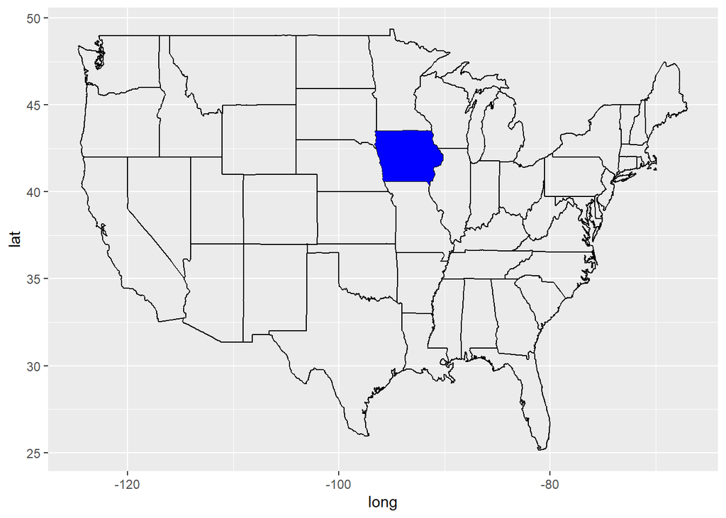

```r
states <- map_data('state')

iowa <- c("iowa")

states %>% ggplot(aes(x = long, y = lat)) +
  geom_path(aes(group = group)) +
  geom_polygon(fill="blue", data = filter(states, region %in% iowa))
```

**Bridge Assets**

**How/do bridge/culvert work types related to the federal work types: construction, replacement, reconstruction, maintenance or preservation?**

Created a dataframe containing only bridge and culvert projects list in the Iowa DOT’s 5 Year Program and sorted the projects into the federal work types. Named the dataframe *Bridge*. SHowing the first 6 records of the dataframe in the output.

```r
Bridge <- FiveYear %>%
  select(Location, Miles, Work, `2021`,
         `2022`, `2023`, `2024`, `2025`) %>%
  filter(grepl(c("BRIDGE|CULVERT"), Work)) %>%
  mutate(FedWork = str_replace_all(Work, c("BRIDGE PAINTING|BRIDGE CLEANING" = "Preservation",
                                           "CULVERT EXTENSION|CULVERT REPAIR" = "Maintenance",
                                           "BRIDGE DECK OVERLAY|BRIDGE REHABILITATION" = "Rehabilitation",
                                           "BRIDGE REPLACEMENT|CULVERT REPLACEMENT|BRIDGE REMOVAL" = "Replacement",
                                           "BRIDGE NEW|CULVERT NEW|PIPE CULVERTS|BRIDGE WIDENING" = "Construction")))

head(Bridge)
```

```
## # A tibble: 6 x 9
## # Groups:   Location [6]
##   Location           Miles Work      `2021` `2022` `2023` `2024` `2025` FedWork
##   <chr>              <dbl> <chr>      <dbl>  <dbl>  <dbl>  <dbl>  <dbl> <chr>
## 1 I-80 INTERCHANGE      NA BRIDGE D~     NA    333     NA     NA     NA Rehabil~
## 2 GRAND RIVER 1.0 M~    NA BRIDGE D~     NA     NA     NA     NA    490 Rehabil~
## 3 W FORK NODAWAY RI~    NA BRIDGE R~     NA     NA     NA   1800     NA Replace~
## 4 MIDDLE NODAWAY RI~    NA BRIDGE D~    712     NA     NA     NA     NA Rehabil~
## 5 MISSISSIPPI RIVER~    NA BRIDGE R~     NA     NA     NA  34438     NA Replace~
## 6 MISSISSIPPI RIVER~    NA BRIDGE C~     20     20     20     20     20 Preserv~
```

**How do funding levels in the 5 Year Program compare to those in the Asset Management Plan?**

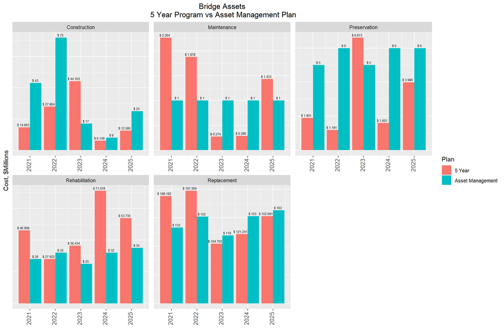

```r
Bri1 <- Bridge %>%
  group_by(FedWork) %>%
  summarise(`20215YrPlan` = sum(`2021`/1000, na.rm = TRUE),
            `20225YrPlan` = sum(`2022`/1000, na.rm = TRUE),
            `20235YrPlan` = sum(`2023`/1000, na.rm = TRUE),
            `20245YrPlan` = sum(`2024`/1000, na.rm = TRUE),
            `20255YrPlan` = sum(`2025`/1000, na.rm = TRUE)) %>%
  add_column(`2021Asset` = c(43, 1, 5, 28, 133),
             `2022Asset` = c(72, 1, 6, 32, 152),
             `2023Asset` = c(17, 1, 5, 25, 119),
             `2024Asset` = c(8, 1, 6, 32, 153),
             `2025Asset` = c(25, 1, 6, 35, 163)) %>%
  pivot_longer(`20215YrPlan`:`2025Asset`, names_to="Year",
               values_to = "Cost") %>%
  mutate(Plan = str_replace_all(Year, c("20215YrPlan|20225YrPlan|20235YrPlan|20245YrPlan|20255YrPlan" = "5 Year",
                                        "2021Asset|2022Asset|2023Asset|2024Asset|2025Asset" = "Asset Management"))) %>%
  mutate(Year2 = str_replace_all(Year, c("20215YrPlan|2021Asset" = "2021", "20225YrPlan|2022Asset" ="2022",
                                        "20235YrPlan|2023Asset" = "2023", "20245YrPlan|2024Asset" = "2024",
                                        "20255YrPlan|2025Asset" = "2025"))) %>%
  select(-Year) %>%
  rename(Year = Year2) %>%
  mutate(Year = as.numeric(Year))



ggplot(Bri1, aes(Year, Cost, fill=Plan)) +
  geom_bar(stat='identity', position = "dodge") +
  ggtitle("Bridge Assets\n 5 Year Program vs Asset Management Plan") +
  labs(y="Cost, $Millions", x="") +
  theme(axis.text.x = element_text(angle = 90, size = 10, vjust = 0.2, hjust = 1)) +
  theme(plot.title = element_text(hjust = 0.5)) +
  theme(axis.ticks.y=element_blank()) +
  theme(axis.text.y = element_blank()) +
  facet_wrap(~FedWork, scales = "free") +
  geom_text(aes(x=Year,y=Cost,label=paste("$",Cost)),
            position = position_dodge(0.9), vjust=-0.5, hjust=0.6, size=2)
```

**Compare the five year total of the 5 Year Program to the Asset Management Plan.**

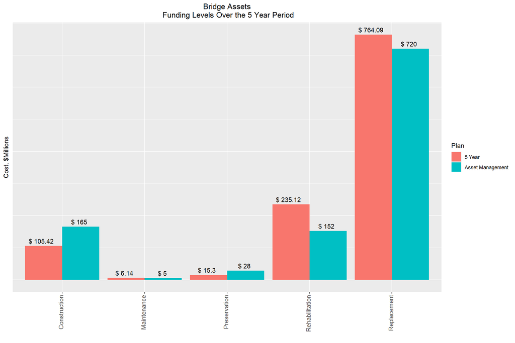

```r
Bri1a <- Bri1 %>%
  group_by(FedWork, Plan) %>%
  summarise(Cost = sum(Cost)) %>%
  mutate(Cost = round(Cost, 2))

Bri1b <- Bri1a %>%
  group_by(Plan) %>%
  summarise(FiveYear = sum(Cost))


ggplot(Bri1a, aes(FedWork, Cost, fill = Plan)) +
  geom_bar(stat='identity', position="dodge") +
  ggtitle("Bridge Assets\n Funding Levels Over the 5 Year Period") +
  labs(x="", y="Cost, $Millions") +
  theme(axis.text.x = element_text(angle = 90, size = 10, vjust = 0.2, hjust = 1)) +
  theme(plot.title = element_text(hjust = 0.5)) +
  theme(axis.ticks.y=element_blank()) +
  theme(axis.text.y = element_blank()) +
  geom_text(aes(x=FedWork,y=Cost,label=paste("$",Cost)),
            position = position_dodge(0.9), vjust=-0.5, hjust=0.6)
```

```r
Bri1b
```

```
## # A tibble: 2 x 2
##   Plan             FiveYear
##   <chr>               <dbl>
## 1 5 Year              1126.
## 2 Asset Management    1070
```

**Pavement Assets**

**How many pavement projects are included in the federal work types: construction, replacement, reconstruction, maintenance or preservation?**

```r
Pavement <- FiveYear %>%
  select(County, District, Route, Location, Miles, Work, `2021`,
         `2022`, `2023`, `2024`, `2025`) %>%
  filter(grepl(c("GRADE|PAVE|PAVING|PAVEMENT|GRADING|RIGHT|SLOPE|TRAFFIC|EROSION|BARRIER|MISCELLANEOUS|NOISE"), Work))

head(Pavement)
```

```
## # A tibble: 6 x 11
## # Groups:   Location [4]
##   County  District Route Location Miles Work  `2021` `2022` `2023` `2024` `2025`
##   <chr>      <dbl> <dbl> <chr>    <dbl> <chr>  <dbl>  <dbl>  <dbl>  <dbl>  <dbl>
## 1 Adair          4    25 GREENFI~  12.3 PAVE~   1350     NA     NA     NA     NA
## 2 Adair          4    80 CASS CO~  13   PAVE~     NA     NA     NA     NA   8977
## 3 Adair          4    80 IA 25 T~  11.5 PAVE~     NA   2866     NA     NA     NA
## 4 Allama~        2     9 MISSISS~  NA   GRAD~     NA     NA     NA   2470     NA
## 5 Allama~        2     9 MISSISS~  NA   RIGH~     NA     NA     NA    116     NA
## 6 Allama~        2     9 MISSISS~  NA   TRAF~     NA     NA     NA    100     NA
```

**Compare the five year total of the 5 Year Program to the Asset Management Plan.**

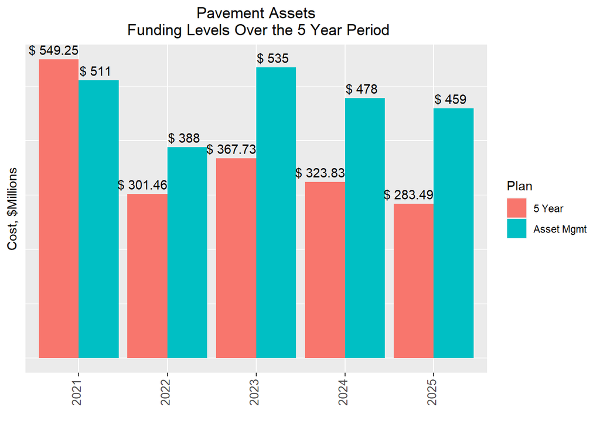

```r
Pave1 <- Pavement %>%
  pivot_longer('2021':'2025', names_to='Year', values_to='Cost') %>%
  filter(Cost != "NA") %>%
  group_by(Year) %>%
  summarise(Cost = sum(Cost)/1000) %>%
  mutate(Cost = round(Cost, 2)) %>%
  add_column(Plan = c( "5 Year", "5 Year", "5 Year", "5 Year", "5 Year")) %>%
  relocate(Plan) %>%
  add_row(Cost = c(511, 388, 535, 478, 459),
          Plan = c("Asset Mgmt", "Asset Mgmt", "Asset Mgmt", "Asset Mgmt", "Asset Mgmt"),
          Year = c("2021", "2022", "2023", "2024", "2025"))

Pave2 <- Pave1 %>%
  group_by(Plan)%>%
  summarise(Cost = sum(Cost))

ggplot(Pave1, aes(Year, Cost, fill = Plan)) +
  geom_bar(stat='identity', position="dodge") +
  ggtitle("Pavement Assets\n Funding Levels Over the 5 Year Period") +
  labs(x="", y="Cost, $Millions") +
  theme(axis.text.x = element_text(angle = 90, size = 10, vjust = 0.2, hjust = 1)) +
  theme(plot.title = element_text(hjust = 0.5)) +
  theme(axis.ticks.y=element_blank()) +
  theme(axis.text.y = element_blank()) +
  geom_text(aes(x=Year,y=Cost,label=paste("$",Cost)),
            position = position_dodge(0.9), vjust=-0.5, hjust=0.6)
```

```r
Pave2
```

```
## # A tibble: 2 x 2
##   Plan        Cost
##   <chr>      <dbl>
## 1 5 Year     1826.
## 2 Asset Mgmt 2371
```